# Caso CPS: ¿Qué Impulsa los Ingresos?

## Análisis visual de los drivers de income — Metodología "De Modelos de ML a Estrategia" (IPADE)

**Materia:** Progressive Digital Marketing — MEDE 2024-2026 **Dataset:** Current Population Survey, marzo 2009 (`cps09mar.csv`) **Objetivo:** **Explicar y entender** qué variables demográficas y laborales explican las diferencias de ingreso. *No predecir, interpretar.*

### Estructura del notebook

1. **Planteamiento del problema de negocio**
2. **EDA visual exhaustivo** — entender la data antes de modelar
3. **Limpieza con antes/después visual**
4. **Feature engineering visualizado**
5. **Modelaje** (5 modelos) — cada uno con sus propios diagnósticos visuales
6. **Evaluación comparativa visual** — múltiples ángulos
7. **Interpretación visual completa** — FI, PDP, SHAP global y local
8. **Estrategia y conclusiones**

## 1. Planteamiento del problema

### 1.1 La pregunta de negocio

> **¿Existe una relación entre el ingreso de un individuo y sus variables demográficas y laborales? ¿Cuáles variables explican mejor las diferencias de ingreso, y en qué dirección?**

Relevante para:

- **HR / Total Rewards:** detectar brechas inequitativas controlando por factores legítimos.
- **Marketing:** segmentación de poder adquisitivo.
- **Políticas públicas:** entender drivers de desigualdad económica.

### 1.2 Los datos: 50,742 individuos × 12 variables

`cps09mar.csv` — extracto del Current Population Survey marzo 2009 (full-time workers, no militares).

| Variable | Tipo | Descripción |
| --- | --- | --- |
| `age` | continua | Edad (tope 85) |
| `female` | binaria | 1 = mujer |
| `hisp` | binaria | 1 = hispano/latino |
| `education` | ordinal | 0–20 (años aprox. de educación) |
| `earnings` | **target** | Ingreso anual USD |
| `hours` | continua | Horas/semana |
| `week` | continua | Semanas/año |
| `union` | binaria | 1 = miembro sindicato |
| `uncov` | binaria | 1 = cubierto por contrato sindical |
| `region` | nominal | 1=NE, 2=MW, 3=S, 4=W |
| `race` | nominal | 1–21 (lo agruparemos) |
| `marital` | nominal | 1–7 (estado civil) |

### 1.3 Enfoque

- **Variable objetivo:** `log(earnings)` → regresión.
- **¿Por qué log?** Ingresos están muy sesgados a la derecha. El log normaliza la distribución y los coeficientes se vuelven "% de cambio en ingreso", lenguaje gerencial.
- **¿Por qué varios modelos?** Cada uno aporta una pieza distinta de la historia: OLS da coeficientes interpretables con p-values (lo que pide la nota IPADE), Lasso selecciona variables, el árbol da reglas legibles, Random Forest captura no-linealidades, Gradient Boosting es el benchmark de rendimiento.

> 📌 **Recordatorio IPADE:** importancia ≠ causalidad. Los modelos describen asociaciones, no causas.

## 2. EDA visual exhaustivo

Antes de tocar cualquier modelo, vamos a **mirar los datos con calma**. La meta de esta sección es que para el final tengas una intuición fuerte de qué está pasando.

```python
# Imports y configuración
import numpy as np
import pandas as pd
import matplotlib.pyplot as plt
import matplotlib.patches as mpatches
from matplotlib.colors import LinearSegmentedColormap
import seaborn as sns
import warnings
warnings.filterwarnings('ignore')

# Estilo consistente
sns.set_style('whitegrid')
plt.rcParams['figure.dpi'] = 95
plt.rcParams['axes.titlesize'] = 12
plt.rcParams['axes.labelsize'] = 11

# Paleta consistente
PALETTE = {
    'primary':   '#2E86AB',
    'secondary': '#A23B72',
    'success':   '#06A77D',
    'warning':   '#F18F01',
    'danger':    '#C73E1D',
    'neutral':   '#6C757D'
}

RANDOM_STATE = 42

# Cargar datos
df = pd.read_csv('cps09mar.csv')
print(f"✓ Dataset cargado: {df.shape[0]:,} filas × {df.shape[1]} columnas")
df.head()
```

```
✓ Dataset cargado: 50,742 filas × 12 columnas
```

|  | age | female | hisp | education | earnings | hours | week | union | uncov | region | race | marital |
| --- | --- | --- | --- | --- | --- | --- | --- | --- | --- | --- | --- | --- |
| 0 | 52 | 0 | 0 | 12 | 146000 | 45 | 52 | 0 | 0 | 1 | 1 | 1 |
| 1 | 38 | 0 | 0 | 18 | 50000 | 45 | 52 | 0 | 0 | 1 | 1 | 1 |
| 2 | 38 | 0 | 0 | 14 | 32000 | 40 | 51 | 0 | 0 | 1 | 1 | 1 |
| 3 | 41 | 1 | 0 | 13 | 47000 | 40 | 52 | 0 | 0 | 1 | 1 | 1 |
| 4 | 42 | 0 | 0 | 13 | 161525 | 50 | 52 | 1 | 0 | 1 | 1 | 1 |

### 2.1 Panorámica general — un solo vistazo a TODO

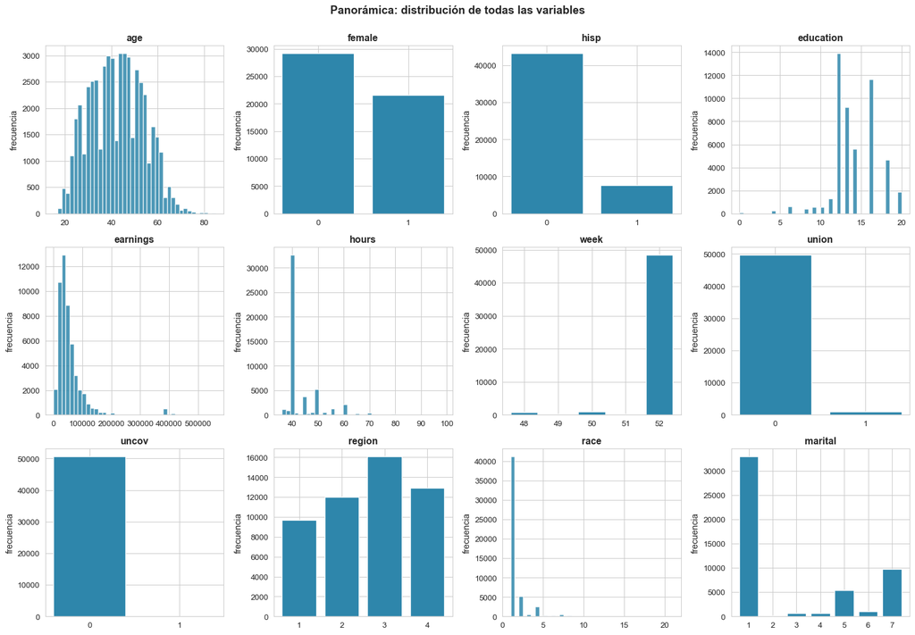

```python
# Vista panorámica: distribución de TODAS las variables a la vez
fig, axes = plt.subplots(3, 4, figsize=(16, 11))
fig.suptitle('Panorámica: distribución de todas las variables', fontsize=14, fontweight='bold', y=1.00)

for ax, col in zip(axes.flat, df.columns):
    if df[col].nunique() <= 10:
        # Variables categóricas / binarias / pocos valores
        counts = df[col].value_counts().sort_index()
        ax.bar(range(len(counts)), counts.values, color=PALETTE['primary'], edgecolor='white')
        ax.set_xticks(range(len(counts)))
        ax.set_xticklabels(counts.index, rotation=0)
    else:
        # Variables continuas
        ax.hist(df[col], bins=40, color=PALETTE['primary'], edgecolor='white', alpha=0.85)
    ax.set_title(col, fontweight='bold')
    ax.set_ylabel('frecuencia')

plt.tight_layout()
plt.show()
```

**Lo que se ve de un vistazo:**

- `earnings` tiene una cola larga a la derecha (asimetría fuerte).
- `education` es ordinal con concentración en 12 (high school) y 16 (bachelor's).
- `age` está bien distribuida.
- `female`, `hisp`, `union`, `uncov` están desbalanceadas (mayoría negativa).
- `race` está dominada por una sola categoría (white).

### 2.2 La variable objetivo en profundidad

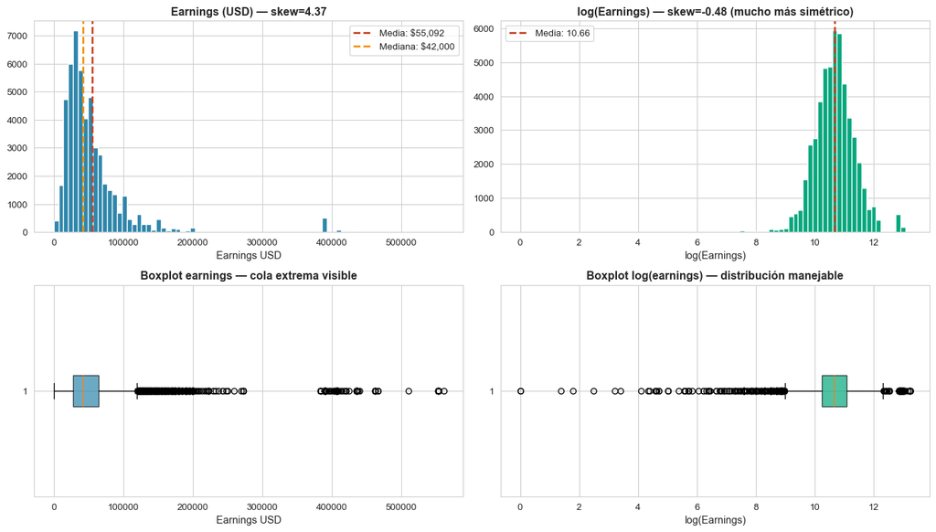

```
Earnings: min=$1, max=$561,087
P5=$15,000, P95=$125,285
```

```python
# Earnings: original vs log, con estadísticas
fig, axes = plt.subplots(2, 2, figsize=(14, 8))

# Histograma original
axes[0,0].hist(df['earnings'], bins=80, color=PALETTE['primary'], edgecolor='white')
axes[0,0].axvline(df['earnings'].mean(), color=PALETTE['danger'], linestyle='--', linewidth=2, label=f"Media: ${df['earnings'].mean():,.0f}")
axes[0,0].axvline(df['earnings'].median(), color=PALETTE['warning'], linestyle='--', linewidth=2, label=f"Mediana: ${df['earnings'].median():,.0f}")
axes[0,0].set_title(f'Earnings (USD) — skew={df["earnings"].skew():.2f}', fontweight='bold')
axes[0,0].set_xlabel('Earnings USD')
axes[0,0].legend()

# Histograma log
log_earn = np.log(df['earnings'])
axes[0,1].hist(log_earn, bins=80, color=PALETTE['success'], edgecolor='white')
axes[0,1].axvline(log_earn.mean(), color=PALETTE['danger'], linestyle='--', linewidth=2, label=f'Media: {log_earn.mean():.2f}')
axes[0,1].set_title(f'log(Earnings) — skew={log_earn.skew():.2f} (mucho más simétrico)', fontweight='bold')
axes[0,1].set_xlabel('log(Earnings)')
axes[0,1].legend()

# Boxplot original (para ver outliers)
axes[1,0].boxplot(df['earnings'], vert=False, patch_artist=True,
                   boxprops=dict(facecolor=PALETTE['primary'], alpha=0.7))
axes[1,0].set_title('Boxplot earnings — cola extrema visible', fontweight='bold')
axes[1,0].set_xlabel('Earnings USD')

# Boxplot log
axes[1,1].boxplot(log_earn, vert=False, patch_artist=True,
                   boxprops=dict(facecolor=PALETTE['success'], alpha=0.7))
axes[1,1].set_title('Boxplot log(earnings) — distribución manejable', fontweight='bold')
axes[1,1].set_xlabel('log(Earnings)')

plt.tight_layout()
plt.show()

print(f"Earnings: min=${df['earnings'].min():,}, max=${df['earnings'].max():,}")
print(f"P5=${df['earnings'].quantile(0.05):,.0f}, P95=${df['earnings'].quantile(0.95):,.0f}")
```

**Conclusión visual:** la transformación log es **obligatoria**. La distribución original tiene la cola del 1% más rico distorsionándolo todo. El log nos da una distribución casi normal, donde los modelos lineales funcionan bien.

### 2.3 Relaciones bivariadas con earnings — el corazón del EDA

Aquí miramos earnings vs cada predictor por separado. Es donde nacen las hipótesis.

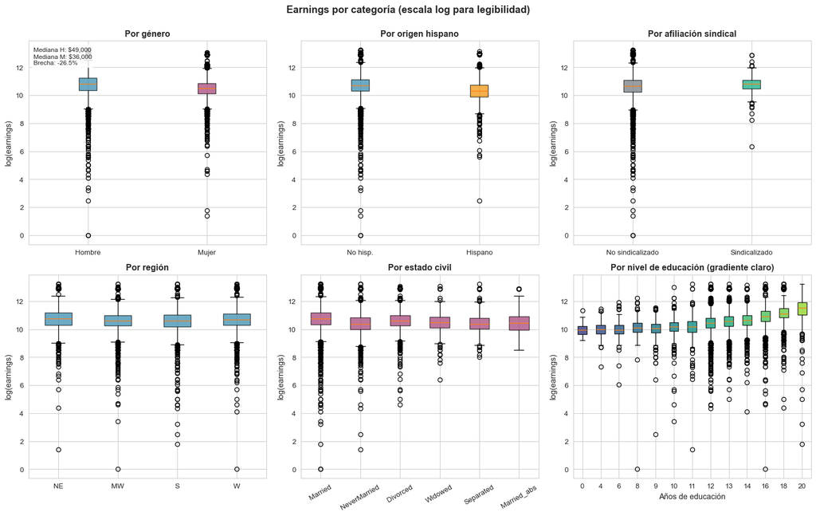

```python
# Mapping para etiquetas legibles
region_map = {1: 'NE', 2: 'MW', 3: 'S', 4: 'W'}
marital_map = {1:'Married', 2:'Married', 3:'Married_abs', 4:'Widowed', 5:'Divorced', 6:'Separated', 7:'NeverMarried'}

df['region_lbl'] = df['region'].map(region_map)
df['marital_lbl'] = df['marital'].map(marital_map)

# Earnings vs variables binarias/categóricas — boxplots
fig, axes = plt.subplots(2, 3, figsize=(16, 10))
fig.suptitle('Earnings por categoría (escala log para legibilidad)', fontsize=14, fontweight='bold', y=1.00)

# 1. Género
data_gender = [np.log(df[df['female']==0]['earnings']), np.log(df[df['female']==1]['earnings'])]
bp = axes[0,0].boxplot(data_gender, patch_artist=True, labels=['Hombre','Mujer'])
for patch, color in zip(bp['boxes'], [PALETTE['primary'], PALETTE['secondary']]):
    patch.set_facecolor(color); patch.set_alpha(0.7)
axes[0,0].set_title('Por género', fontweight='bold')
axes[0,0].set_ylabel('log(earnings)')
m_h = df[df['female']==0]['earnings'].median()
m_m = df[df['female']==1]['earnings'].median()
axes[0,0].text(0.02, 0.97, f'Mediana H: ${m_h:,.0f}\nMediana M: ${m_m:,.0f}\nBrecha: {(m_m/m_h-1)*100:.1f}%',
               transform=axes[0,0].transAxes, va='top', fontsize=9,
               bbox=dict(boxstyle='round', facecolor='white', alpha=0.85))

# 2. Hispanic
data_hisp = [np.log(df[df['hisp']==0]['earnings']), np.log(df[df['hisp']==1]['earnings'])]
bp = axes[0,1].boxplot(data_hisp, patch_artist=True, labels=['No hisp.','Hispano'])
for patch, color in zip(bp['boxes'], [PALETTE['primary'], PALETTE['warning']]):
    patch.set_facecolor(color); patch.set_alpha(0.7)
axes[0,1].set_title('Por origen hispano', fontweight='bold')
axes[0,1].set_ylabel('log(earnings)')

# 3. Union
data_union = [np.log(df[df['union']==0]['earnings']), np.log(df[df['union']==1]['earnings'])]
bp = axes[0,2].boxplot(data_union, patch_artist=True, labels=['No sindicalizado','Sindicalizado'])
for patch, color in zip(bp['boxes'], [PALETTE['neutral'], PALETTE['success']]):
    patch.set_facecolor(color); patch.set_alpha(0.7)
axes[0,2].set_title('Por afiliación sindical', fontweight='bold')
axes[0,2].set_ylabel('log(earnings)')

# 4. Región
regions_order = ['NE','MW','S','W']
data_region = [np.log(df[df['region_lbl']==r]['earnings']) for r in regions_order]
bp = axes[1,0].boxplot(data_region, patch_artist=True, labels=regions_order)
for patch in bp['boxes']:
    patch.set_facecolor(PALETTE['primary']); patch.set_alpha(0.7)
axes[1,0].set_title('Por región', fontweight='bold')
axes[1,0].set_ylabel('log(earnings)')

# 5. Estado civil
marital_order = ['Married', 'NeverMarried', 'Divorced', 'Widowed', 'Separated', 'Married_abs']
marital_avail = [m for m in marital_order if m in df['marital_lbl'].unique()]
data_marital = [np.log(df[df['marital_lbl']==m]['earnings']) for m in marital_avail]
bp = axes[1,1].boxplot(data_marital, patch_artist=True, labels=marital_avail)
for patch in bp['boxes']:
    patch.set_facecolor(PALETTE['secondary']); patch.set_alpha(0.7)
axes[1,1].set_title('Por estado civil', fontweight='bold')
axes[1,1].set_ylabel('log(earnings)')
axes[1,1].tick_params(axis='x', rotation=30)

# 6. Educación (es ordinal pero la tratamos visualmente)
educ_levels = sorted(df['education'].unique())
data_educ = [np.log(df[df['education']==e]['earnings']) for e in educ_levels]
bp = axes[1,2].boxplot(data_educ, patch_artist=True, labels=educ_levels)
# Colorear con gradiente: menos educación más oscuro
n_levels = len(educ_levels)
colors_grad = plt.cm.viridis(np.linspace(0.2, 0.85, n_levels))
for patch, color in zip(bp['boxes'], colors_grad):
    patch.set_facecolor(color); patch.set_alpha(0.85)
axes[1,2].set_title('Por nivel de educación (gradiente claro)', fontweight='bold')
axes[1,2].set_xlabel('Años de educación')
axes[1,2].set_ylabel('log(earnings)')

plt.tight_layout()
plt.show()
```

**Lo que estos boxplots gritan:**

- **Género:** hay una brecha clara incluso sin controlar por nada más.
- **Hispano:** brecha visible aunque más pequeña.
- **Union:** sindicalizados ganan más en mediana (probablemente correlacionado con industria).
- **Region:** NE y W tienen distribuciones más altas.
- **Marital:** los married ganan más que solteros — el famoso "marriage premium".
- **Educación:** gradiente perfecto. Cada escalón sube. Es nuestro driver más prometedor.

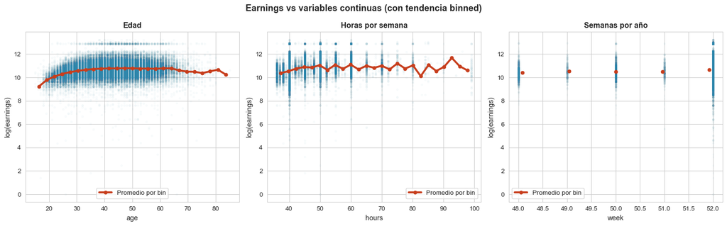

```python
# Relaciones con variables continuas: scatter con regresión local
from scipy.stats import binned_statistic

fig, axes = plt.subplots(1, 3, figsize=(16, 5))
fig.suptitle('Earnings vs variables continuas (con tendencia binned)', fontsize=14, fontweight='bold')

log_earn = np.log(df['earnings'])

for ax, var, title in zip(axes,
                          ['age', 'hours', 'week'],
                          ['Edad', 'Horas por semana', 'Semanas por año']):
    # Scatter alpha bajo (muchos puntos)
    ax.scatter(df[var], log_earn, alpha=0.02, s=8, color=PALETTE['primary'])

    # Tendencia binned (media por bin)
    means, edges, _ = binned_statistic(df[var], log_earn, statistic='mean', bins=25)
    centers = (edges[:-1] + edges[1:]) / 2
    ax.plot(centers, means, color=PALETTE['danger'], linewidth=3, marker='o', markersize=5, label='Promedio por bin')

    ax.set_title(title, fontweight='bold')
    ax.set_xlabel(var)
    ax.set_ylabel('log(earnings)')
    ax.legend()

plt.tight_layout()
plt.show()
```

### 2.4 Brecha de género desglosada — la pregunta más sensible

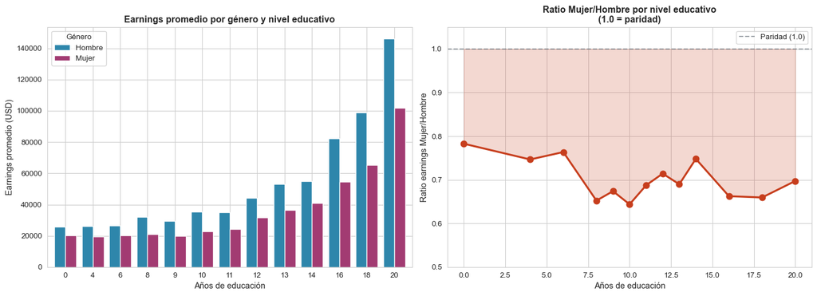

```
Ratio Mujer/Hombre en niveles clave:
  Educación 12: 0.71 (la mujer gana 71% de lo que gana el hombre)
  Educación 14: 0.75 (la mujer gana 75% de lo que gana el hombre)
  Educación 16: 0.66 (la mujer gana 66% de lo que gana el hombre)
  Educación 18: 0.66 (la mujer gana 66% de lo que gana el hombre)
  Educación 20: 0.70 (la mujer gana 70% de lo que gana el hombre)
```

```python
# Brecha de género POR nivel de educación — ¿se cierra la brecha con más educación?
fig, axes = plt.subplots(1, 2, figsize=(15, 5.5))

# Panel izquierdo: medias por educación y género
gender_educ = df.groupby(['education','female'])['earnings'].mean().unstack()
gender_educ.columns = ['Hombre', 'Mujer']
gender_educ.plot(kind='bar', ax=axes[0], color=[PALETTE['primary'], PALETTE['secondary']], edgecolor='white', width=0.8)
axes[0].set_title('Earnings promedio por género y nivel educativo', fontweight='bold')
axes[0].set_xlabel('Años de educación')
axes[0].set_ylabel('Earnings promedio (USD)')
axes[0].legend(title='Género')
axes[0].tick_params(axis='x', rotation=0)

# Panel derecho: ratio mujer/hombre por educación
ratio = gender_educ['Mujer'] / gender_educ['Hombre']
axes[1].plot(ratio.index, ratio.values, marker='o', linewidth=2.5, color=PALETTE['danger'], markersize=8)
axes[1].axhline(1.0, color=PALETTE['neutral'], linestyle='--', alpha=0.7, label='Paridad (1.0)')
axes[1].fill_between(ratio.index, ratio.values, 1.0, alpha=0.2, color=PALETTE['danger'])
axes[1].set_title('Ratio Mujer/Hombre por nivel educativo\n(1.0 = paridad)', fontweight='bold')
axes[1].set_xlabel('Años de educación')
axes[1].set_ylabel('Ratio earnings Mujer/Hombre')
axes[1].set_ylim(0.5, 1.05)
axes[1].legend()

plt.tight_layout()
plt.show()

print("Ratio Mujer/Hombre en niveles clave:")
for ed in [12, 14, 16, 18, 20]:
    if ed in ratio.index:
        print(f"  Educación {ed}: {ratio[ed]:.2f} (la mujer gana {ratio[ed]*100:.0f}% de lo que gana el hombre)")
```

**Hallazgo poderoso:** la brecha de género **NO se cierra** con más educación. De hecho, en algunos niveles es más grande en niveles educativos altos. Esto es justamente lo que motiva la distinción "inequality vs inequity" de la nota CPS.

### 2.5 Matriz de correlación

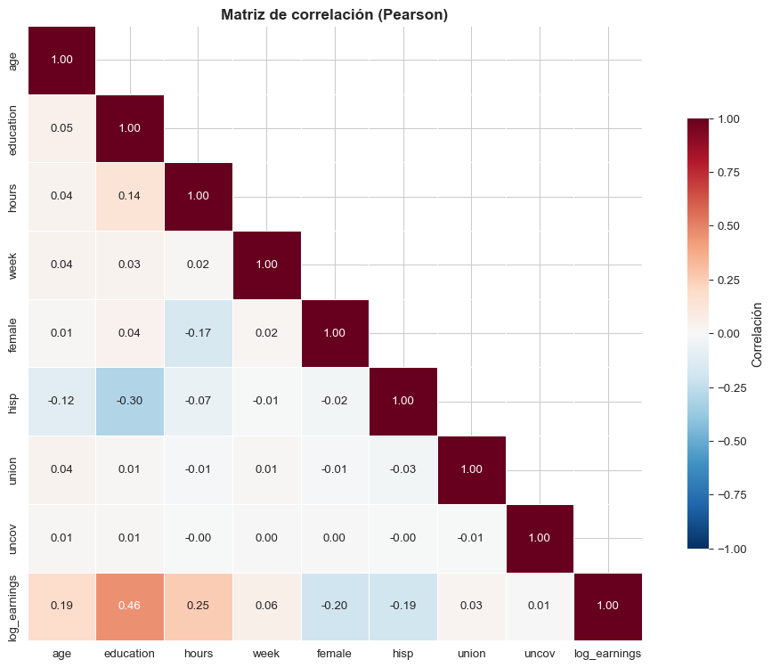

```
Correlaciones con log(earnings) ordenadas por magnitud:
education    0.456
hours        0.250
female       0.203
hisp         0.188
age          0.187
week         0.059
union        0.025
uncov        0.005
Name: log_earnings, dtype: float64
```

```python
# Correlaciones entre variables numéricas
fig, ax = plt.subplots(figsize=(11, 8))

corr_vars = ['age','education','hours','week','female','hisp','union','uncov']
corr_with_target = df[corr_vars + ['earnings']].copy()
corr_with_target['log_earnings'] = np.log(corr_with_target['earnings'])
corr_with_target = corr_with_target.drop(columns=['earnings'])

corr = corr_with_target.corr()

# Heatmap con anotaciones
mask = np.triu(np.ones_like(corr, dtype=bool), k=1)
sns.heatmap(corr, mask=mask, annot=True, fmt='.2f', cmap='RdBu_r', center=0,
            vmin=-1, vmax=1, square=True, linewidths=0.5,
            cbar_kws={'shrink': 0.7, 'label': 'Correlación'}, ax=ax)
ax.set_title('Matriz de correlación (Pearson)', fontweight='bold', fontsize=13)
plt.tight_layout()
plt.show()

print("\nCorrelaciones con log(earnings) ordenadas por magnitud:")
print(corr['log_earnings'].drop('log_earnings').abs().sort_values(ascending=False).round(3))
```

**Lectura:**

- `education` tiene la correlación positiva más fuerte con log(earnings).
- `female` y `hisp` tienen correlación negativa.
- `age`, `hours`, `week` también positivas.
- No hay multicolinealidad alarmante entre predictores (todas las correlaciones inter-predictor < 0.5).

## 3. Limpieza con antes/después visual

Mostramos el efecto de cada paso de limpieza visualmente.

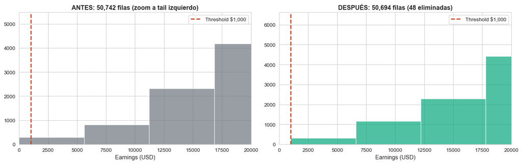

```
✓ Filtramos 48 filas con earnings < $1,000 (improbables para full-time annual)
```

```python
# 3.1 Visualizar antes/después de filtrar earnings muy bajos
fig, axes = plt.subplots(1, 2, figsize=(14, 4.5))

# Antes
axes[0].hist(df['earnings'], bins=100, color=PALETTE['neutral'], edgecolor='white', alpha=0.7)
axes[0].axvline(1000, color=PALETTE['danger'], linestyle='--', linewidth=2, label='Threshold $1,000')
axes[0].set_xlim(0, 20000)
axes[0].set_title(f'ANTES: {len(df):,} filas (zoom a tail izquierdo)', fontweight='bold')
axes[0].set_xlabel('Earnings (USD)')
axes[0].legend()

# Filtrar
filtered_low = (df['earnings'] < 1000).sum()
df = df[df['earnings'] >= 1000].copy()

# Después
axes[1].hist(df['earnings'], bins=100, color=PALETTE['success'], edgecolor='white', alpha=0.7)
axes[1].axvline(1000, color=PALETTE['danger'], linestyle='--', linewidth=2, label='Threshold $1,000')
axes[1].set_xlim(0, 20000)
axes[1].set_title(f'DESPUÉS: {len(df):,} filas ({filtered_low} eliminadas)', fontweight='bold')
axes[1].set_xlabel('Earnings (USD)')
axes[1].legend()

plt.tight_layout()
plt.show()
print(f"✓ Filtramos {filtered_low} filas con earnings < $1,000 (improbables para full-time annual)")
```

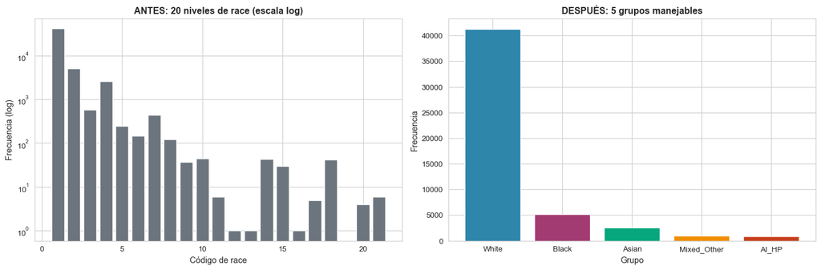

```
Distribución final de race_group:
race_group
White          41243
Black           5125
Asian           2582
Mixed_Other      924
AI_HP            820
```

```python
# 3.2 Agrupar race — visualizar antes/después
def race_group(r):
    if r == 1: return 'White'
    elif r == 2: return 'Black'
    elif r == 4: return 'Asian'
    elif r in [3, 5]: return 'AI_HP'
    else: return 'Mixed_Other'

df['race_group'] = df['race'].apply(race_group)
df['log_earnings'] = np.log(df['earnings'])

fig, axes = plt.subplots(1, 2, figsize=(15, 5))

# Antes: 21 niveles
race_counts_before = df['race'].value_counts().sort_index()
axes[0].bar(race_counts_before.index, race_counts_before.values, color=PALETTE['neutral'], edgecolor='white')
axes[0].set_yscale('log')
axes[0].set_title(f'ANTES: {df["race"].nunique()} niveles de race (escala log)', fontweight='bold')
axes[0].set_xlabel('Código de race')
axes[0].set_ylabel('Frecuencia (log)')

# Después: 5 grupos
race_counts_after = df['race_group'].value_counts()
colors_after = [PALETTE['primary'], PALETTE['secondary'], PALETTE['success'], PALETTE['warning'], PALETTE['danger']]
axes[1].bar(race_counts_after.index, race_counts_after.values, color=colors_after[:len(race_counts_after)], edgecolor='white')
axes[1].set_title(f'DESPUÉS: {df["race_group"].nunique()} grupos manejables', fontweight='bold')
axes[1].set_xlabel('Grupo')
axes[1].set_ylabel('Frecuencia')

plt.tight_layout()
plt.show()

print("Distribución final de race_group:")
print(df['race_group'].value_counts().to_string())
```

## 4. Feature engineering visualizado

### 4.1 ¿Por qué `age²`?

La relación edad-ingreso es cóncava (lo vimos en la sección 2.3). Un modelo lineal puro solo puede ajustar una línea recta — necesita ayuda para capturar la curvatura.

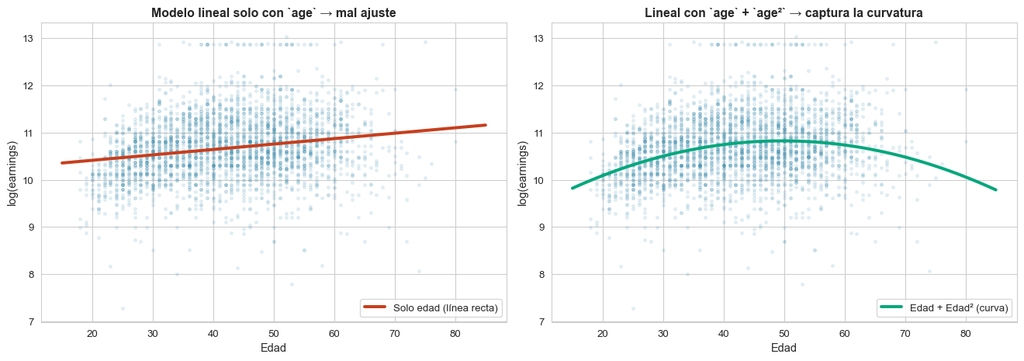

```
R² con solo age:          0.0377
R² con age + age² (cuadr): 0.0725
→ El término cuadrático mejora claramente el ajuste.
```

```python
# Demostrar visualmente por qué age² ayuda
from numpy.polynomial import polynomial as P

fig, axes = plt.subplots(1, 2, figsize=(14, 5))

# Ajuste lineal vs polinomial en edad
x = df['age'].values
y = df['log_earnings'].values

# Sample para que el scatter sea visible
idx_sample = np.random.RandomState(42).choice(len(df), 3000, replace=False)
x_s, y_s = x[idx_sample], y[idx_sample]

# Modelo solo con age
coef_lin = np.polyfit(x, y, 1)
x_grid = np.linspace(x.min(), x.max(), 100)
y_lin = np.polyval(coef_lin, x_grid)

# Modelo con age + age²
coef_quad = np.polyfit(x, y, 2)
y_quad = np.polyval(coef_quad, x_grid)

axes[0].scatter(x_s, y_s, alpha=0.1, s=8, color=PALETTE['primary'])
axes[0].plot(x_grid, y_lin, color=PALETTE['danger'], linewidth=3, label='Solo edad (línea recta)')
axes[0].set_title('Modelo lineal solo con `age` → mal ajuste', fontweight='bold')
axes[0].set_xlabel('Edad')
axes[0].set_ylabel('log(earnings)')
axes[0].legend()

axes[1].scatter(x_s, y_s, alpha=0.1, s=8, color=PALETTE['primary'])
axes[1].plot(x_grid, y_quad, color=PALETTE['success'], linewidth=3, label='Edad + Edad² (curva)')
axes[1].set_title('Lineal con `age` + `age²` → captura la curvatura', fontweight='bold')
axes[1].set_xlabel('Edad')
axes[1].set_ylabel('log(earnings)')
axes[1].legend()

plt.tight_layout()
plt.show()
print(f"R² con solo age:          {np.corrcoef(x, y)[0,1]**2:.4f}")
print(f"R² con age + age² (cuadr): {(np.corrcoef(np.polyval(coef_quad, x), y)[0,1]**2):.4f}")
print("→ El término cuadrático mejora claramente el ajuste.")
```

```python
# Feature engineering completo
df['age_sq'] = df['age'] ** 2

numeric_features = ['age', 'age_sq', 'education', 'hours', 'week']
binary_features  = ['female', 'hisp', 'union', 'uncov']
categorical_features = ['region_lbl', 'marital_lbl', 'race_group']

df_model = pd.get_dummies(
    df[numeric_features + binary_features + categorical_features + ['log_earnings']],
    columns=categorical_features,
    drop_first=True,
    dtype=float
)

print(f"✓ Dataset modelable: {df_model.shape[0]:,} filas × {df_model.shape[1]} columnas")
print(f"  Variables predictoras: {df_model.shape[1]-1}")
print(f"  Predictoras: {[c for c in df_model.columns if c != 'log_earnings']}")
```

```
✓ Dataset modelable: 50,694 filas × 22 columnas
  Variables predictoras: 21
  Predictoras: ['age', 'age_sq', 'education', 'hours', 'week', 'female', 'hisp', 'union', 'uncov', 'region_lbl_NE', 'region_lbl_S', 'region_lbl_W', 'marital_lbl_Married', 'marital_lbl_Married_abs', 'marital_lbl_NeverMarried', 'marital_lbl_Separated', 'marital_lbl_Widowed', 'race_group_Asian', 'race_…
```

### Preparación para modelar: validación cruzada en lugar de holdout

En vez de partir los datos **una sola vez** en *train/test*, evaluaremos cada modelo con **validación cruzada de 5 folds** (5-fold CV):

- Los datos se reparten en 5 bloques. Cada modelo se entrena 5 veces: en cada vuelta un bloque distinto sirve de validación y los otros 4 de entrenamiento.
- La métrica reportada es el **promedio de los 5 folds** ± la **desviación entre folds**. Es un estimado más estable y menos sensible al azar de una partición única.
- Los **modelos finales que vamos a interpretar** (coeficientes OLS/Lasso, feature importance, PDP, SHAP) se ajustan sobre **todos los datos**: para *explicar* conviene usar toda la información disponible.

> 📌 La validación cruzada responde *"¿qué tan bien generaliza?"*; el ajuste sobre el set completo da los *coeficientes e importancias* más precisos para *interpretar*.

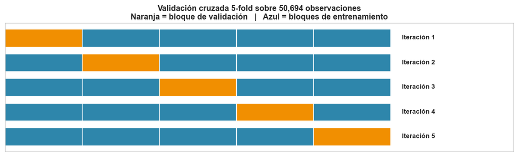

```
✓ X: 50,694 filas × 21 columnas predictoras
✓ CV externa (evaluación): 5 folds  |  CV interna (tuning): 3 folds
  Cada fold externo valida sobre ~10,138 obs. y entrena con ~40,556.
```

```python
# Preparación para modelar — SIN holdout train/test: usaremos validación cruzada
from sklearn.preprocessing import StandardScaler
from sklearn.model_selection import KFold, cross_val_score, GridSearchCV, RandomizedSearchCV
from sklearn.linear_model import LinearRegression
from sklearn.pipeline import make_pipeline
from sklearn.base import clone

y = df_model['log_earnings']
X = df_model.drop(columns=['log_earnings'])

# Estandarización del set COMPLETO (la usan Lasso y los gráficos de coeficientes)
scaler = StandardScaler()
X_scaled = pd.DataFrame(scaler.fit_transform(X), columns=X.columns, index=X.index)

# CV EXTERNA: 5 folds barajados — mide el desempeño final de cada modelo
N_SPLITS = 5
cv = KFold(n_splits=N_SPLITS, shuffle=True, random_state=RANDOM_STATE)

# CV INTERNA: 3 folds — se usa SOLO para el tuning de hiperparámetros.
# Anidar ambas (ver sección 5.0) evita el sesgo de tunear y evaluar con los mismos datos.
INNER_SPLITS = 3
inner_cv = KFold(n_splits=INNER_SPLITS, shuffle=True, random_state=RANDOM_STATE + 1)

# Visualizar el esquema de 5-fold CV (la validación externa)
fig, ax = plt.subplots(figsize=(11, 3.4))
for fold in range(N_SPLITS):
    for block in range(N_SPLITS):
        es_val = (block == fold)
        ax.barh(fold, 1, left=block, height=0.72,
                color=PALETTE['warning'] if es_val else PALETTE['primary'],
                edgecolor='white')
    ax.text(N_SPLITS + 0.15, fold, f'Iteración {fold + 1}', va='center', fontweight='bold')
ax.set_yticks([])
ax.set_xticks([])
ax.set_xlim(0, N_SPLITS + 1.6)
ax.invert_yaxis()
ax.set_title(f'Validación cruzada {N_SPLITS}-fold sobre {len(X):,} observaciones\n'
             'Naranja = bloque de validación   |   Azul = bloques de entrenamiento',
             fontweight='bold')
plt.tight_layout()
plt.show()

print(f"✓ X: {X.shape[0]:,} filas × {X.shape[1]} columnas predictoras")
print(f"✓ CV externa (evaluación): {N_SPLITS} folds  |  CV interna (tuning): {INNER_SPLITS} folds")
print(f"  Cada fold externo valida sobre ~{len(X)//N_SPLITS:,} obs. y entrena con ~{len(X)-len(X)//N_SPLITS:,}.")
```

## 5. Modelaje (5 modelos con diagnóstico visual)

Vamos a entrenar cinco modelos. Después de cada uno, generamos su diagnóstico visual propio.

### 5.0 Tuning de hiperparámetros — sin fugas ni sobreajuste

Antes de entrenar los modelos finales **buscamos sus mejores hiperparámetros** (la "configuración" de cada algoritmo: profundidad del árbol, variables por split, learning rate, etc.). Lo hacemos siguiendo tres reglas para no engañarnos a nosotros mismos:

**1. Sin fuga de datos (data leakage).** Todo preprocesamiento que "aprende" de los datos (la estandarización que usa Lasso) va dentro de un `Pipeline`. Así el `StandardScaler` se ajusta **solo con los datos de entrenamiento** de cada fold, nunca con los de validación.

**2. La búsqueda se evalúa con validación cruzada.** Con `GridSearchCV` / `RandomizedSearchCV` cada combinación de hiperparámetros se puntúa en folds que no participaron en su ajuste. Elegimos la que mejor **generaliza**, no la que mejor memoriza. Además acotamos los rangos hacia la regularización (profundidad limitada, hojas con muchos datos) para no invitar al sobreajuste.

**3. Evaluación honesta con validación cruzada ANIDADA (nested CV).** Aquí está la sutileza clave: *elegir la mejor de muchas combinaciones es, en sí mismo, una forma de sobreajuste* — la "mejor" tiene algo de suerte. Si reportáramos su score de búsqueda estaríamos siendo optimistas. La solución es **anidar dos validaciones cruzadas**:

|  | Rol | Cómo funciona |
| --- | --- | --- |
| **Loop externo** (`cv`, 5 folds) | Mide el desempeño | Cada fold externo se reserva *solo para evaluar* |
| **Loop interno** (`inner_cv`, 3 folds) | Elige los hiperparámetros | Corre *dentro* del train de cada fold externo |

Como el tuning de cada fold externo nunca ve su fold de validación, el R² resultante es un estimado **insesgado** del desempeño real. Eso es lo que compararemos en la sección 6.

> 📌 **OLS** no tiene hiperparámetros que tunear. **Lasso** ya se tunea solo: `LassoCV` elige `alpha` por validación cruzada — es tuning hecho correctamente. Tuneamos por tanto **árbol, Random Forest y Gradient Boosting**.

> ⏱️ La validación cruzada anidada entrena cientos de modelos: **la sección 6 puede tardar varios minutos** al correrla.

### 5.1 OLS — el modelo interpretable por excelencia

```python
import statsmodels.api as sm

# Modelo final OLS: ajustado sobre TODOS los datos para interpretar coeficientes y p-values
X_ols = sm.add_constant(X)
ols_model = sm.OLS(y, X_ols).fit()
print(ols_model.summary())
```

```
                            OLS Regression Results
==============================================================================
Dep. Variable:           log_earnings   R-squared:                       0.367
Model:                            OLS   Adj. R-squared:                  0.367
Method:                 Least Squares   F-statistic:                     1401.
Date:                Fri, 15 May 2026   Prob (F-statistic):               0.00
Time:                        11:46:31   Log-Likelihood:                -40700.
No. Observations:               50694   AIC:                         8.144e+04
Df Residuals:                   50672   BIC:                         8.164e+04
Df Model:                          21
Covariance Type:            nonrobust
============================================================================================
                               coef    std err          t      P>|t|      [0.025      0.975]
--------------------------------------------------------------------------------------------
const                        4.8660      0.211     23.072      0.000       4.453       5.279
age                          0.0581      0.001     39.776      0.000       0.055       0.061
age_sq                      -0.0006   1.66e-05    -35.286      0.000      -0.001      -0.001
education                    0.1032      0.001    110.195      0.000       0.101       0.105
hours                        0.0130      0.000     40.657      0.000       0.012       0.014
week                         0.0463      0.004     11.527      0.000       0.038       0.054
female                      -0.2689      0.005    -53.668      0.000      -0.279      -0.259
hisp                        -0.1026      0.007    -13.994      0.000      -0.117      -0.088
union                        0.0505      0.017      3.050      0.002       0.018       0.083
uncov                        0.0110      0.051      0.215      0.830      -0.089       0.111
region_lbl_NE                0.1217      0.007     16.442      0.000       0.107       0.136
region_lbl_S                 0.0427      0.007      6.416      0.000       0.030       0.056
region_lbl_W                 0.1189      0.007     16.876      0.000       0.105       0.133
marital_lbl_Married          0.0822      0.008     10.236      0.000       0.066       0.098
marital_lbl_Married_abs     -0.0057      0.023     -0.246      0.806      -0.051       0.040
marital_lbl_NeverMarried    -0.0484      0.010     -4.892      0.000      -0.068      -0.029
marital_lbl_Separated       -0.0270      0.018     -1.489      0.136      -0.062       0.009
marital_lbl_Widowed          0.0030      0.022      0.137      0.891      -0.040       0.046
race_group_Asian             0.0287      0.022      1.317      0.188      -0.014       0.071
race_group_Black             0.0007      0.021      0.035      0.972      -0.040       0.041
race_group_Mixed_Other       0.0512      0.026      1.974      0.048       0.000       0.102
race_group_White             0.0930      0.019      4.857      0.000       0.055       0.131
==============================================================================
Omnibus:                     5823.123   Durbin-Watson:                   1.725
Prob(Omnibus):                  0.000   Jarque-Bera (JB):            33034.756
Skew:                          -0.411   Prob(JB):                         0.00
Kurtosis:                       6.868   Cond. No.                     1.89e+05
==============================================================================

Notes:
[1] Standard Errors assume that the covariance matrix of the errors is correctly specified.
[2] The condition number is large, 1.89e+05. This might indicate that there are
strong multicollinearity or other numerical problems.
```

**Cómo leer la tabla (recordando la nota IPADE):**

1. **Signo del coeficiente** → dirección.
2. **Magnitud (|coef|)** → tamaño del efecto (en log = ~% de cambio).
3. **p-value (`P>|t|`)** → confiabilidad. <0.05 significativo.

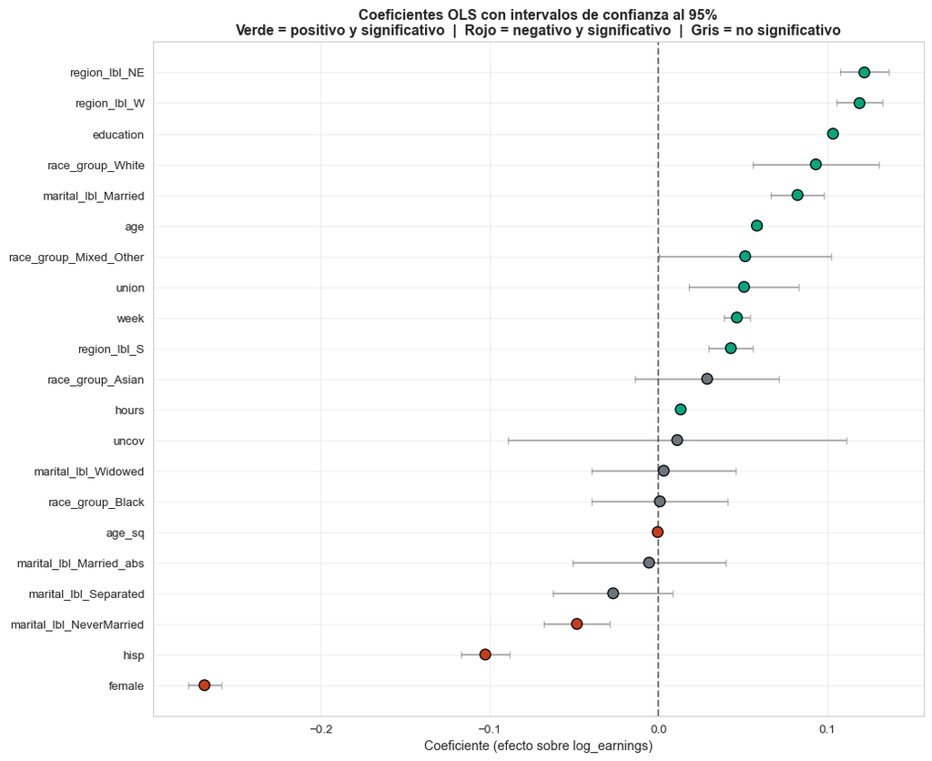

```python
# Visualización de coeficientes OLS — forest plot con intervalos de confianza
coefs_df = pd.DataFrame({
    'coef': ols_model.params,
    'ci_lower': ols_model.conf_int()[0],
    'ci_upper': ols_model.conf_int()[1],
    'p_value': ols_model.pvalues
}).drop('const', errors='ignore')

coefs_df['signif'] = coefs_df['p_value'] < 0.05
coefs_df['pct_effect'] = (np.exp(coefs_df['coef']) - 1) * 100
coefs_df = coefs_df.sort_values('coef')

fig, ax = plt.subplots(figsize=(11, 9))
colors = [PALETTE['success'] if (c > 0 and s) else PALETTE['danger'] if (c < 0 and s) else PALETTE['neutral']
          for c, s in zip(coefs_df['coef'], coefs_df['signif'])]

y_pos = np.arange(len(coefs_df))
ax.errorbar(coefs_df['coef'], y_pos,
            xerr=[coefs_df['coef'] - coefs_df['ci_lower'], coefs_df['ci_upper'] - coefs_df['coef']],
            fmt='none', ecolor='gray', capsize=3, alpha=0.6)
ax.scatter(coefs_df['coef'], y_pos, c=colors, s=80, edgecolor='black', zorder=3)
ax.axvline(0, color='black', linestyle='--', alpha=0.5)
ax.set_yticks(y_pos)
ax.set_yticklabels(coefs_df.index)
ax.set_xlabel('Coeficiente (efecto sobre log_earnings)')
ax.set_title('Coeficientes OLS con intervalos de confianza al 95%\n'
             'Verde = positivo y significativo  |  Rojo = negativo y significativo  |  Gris = no significativo',
             fontweight='bold')
ax.grid(True, alpha=0.3)
plt.tight_layout()
plt.show()
```

```python
# Tabla ordenada por efecto + significancia
coefs_table = coefs_df.copy()
coefs_table['signif_label'] = coefs_table['p_value'].apply(
    lambda p: '***' if p < 0.001 else '**' if p < 0.01 else '*' if p < 0.05 else '.' if p < 0.10 else ''
)
coefs_table[['coef','pct_effect','p_value','signif_label']].sort_values('coef', key=abs, ascending=False).round(4)
```

|  | coef | pct_effect | p_value | signif_label |
| --- | --- | --- | --- | --- |
| female | -0.2689 | -23.5750 | 0.0000 | *** |
| region_lbl_NE | 0.1217 | 12.9440 | 0.0000 | *** |
| region_lbl_W | 0.1189 | 12.6217 | 0.0000 | *** |
| education | 0.1032 | 10.8699 | 0.0000 | *** |
| hisp | -0.1026 | -9.7537 | 0.0000 | *** |
| race_group_White | 0.0930 | 9.7492 | 0.0000 | *** |
| marital_lbl_Married | 0.0822 | 8.5650 | 0.0000 | *** |
| age | 0.0581 | 5.9847 | 0.0000 | *** |
| race_group_Mixed_Other | 0.0512 | 5.2538 | 0.0484 | * |
| union | 0.0505 | 5.1848 | 0.0023 | ** |
| marital_lbl_NeverMarried | -0.0484 | -4.7248 | 0.0000 | *** |
| week | 0.0463 | 4.7359 | 0.0000 | *** |
| region_lbl_S | 0.0427 | 4.3623 | 0.0000 | *** |
| race_group_Asian | 0.0287 | 2.9104 | 0.1878 |  |
| marital_lbl_Separated | -0.0270 | -2.6610 | 0.1365 |  |
| hours | 0.0130 | 1.3110 | 0.0000 | *** |
| uncov | 0.0110 | 1.1034 | 0.8300 |  |
| marital_lbl_Married_abs | -0.0057 | -0.5678 | 0.8057 |  |
| marital_lbl_Widowed | 0.0030 | 0.2997 | 0.8907 |  |
| race_group_Black | 0.0007 | 0.0716 | 0.9722 |  |
| age_sq | -0.0006 | -0.0585 | 0.0000 | *** |

**Interpretación clave del forest plot:**

- Las variables más a la derecha (efecto positivo grande) y a la izquierda (efecto negativo grande) son los drivers principales.
- Las barras de error que cruzan el cero indican variables NO significativas (gris).
- En log, un coeficiente de 0.10 ≈ +10% de earnings; -0.20 ≈ -18% de earnings.

### 5.2 Lasso — selección automática de variables

Para visualizar Lasso, vamos a ver el "camino" de los coeficientes mientras se va aumentando la penalización.

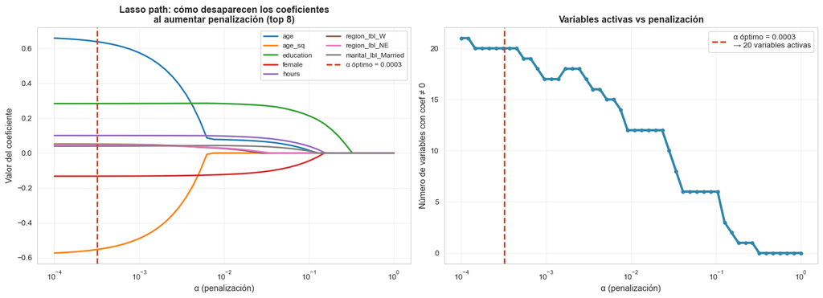

```
α óptimo (elegido por validación cruzada): 0.00032
Variables activas: 20 de 21
```

```python
from sklearn.linear_model import Lasso, LassoCV

# Lasso path: cómo se mueven los coeficientes según alpha (sobre el set completo estandarizado)
alphas = np.logspace(-4, 0, 50)
coefs_path = []
for alpha in alphas:
    l = Lasso(alpha=alpha, max_iter=5000, random_state=RANDOM_STATE)
    l.fit(X_scaled, y)
    coefs_path.append(l.coef_)
coefs_path = np.array(coefs_path)

# LassoCV YA ES tuning de hiperparámetros: elige alpha (la penalización) por
# validación cruzada. Es el "search" del Lasso, hecho correctamente con CV.
lasso = LassoCV(cv=inner_cv, random_state=RANDOM_STATE, n_jobs=-1, max_iter=5000)
lasso.fit(X_scaled, y)
best_alpha = lasso.alpha_

fig, axes = plt.subplots(1, 2, figsize=(15, 5.5))

# Panel 1: el path de Lasso
top_features_idx = np.argsort(np.abs(lasso.coef_))[::-1][:8]
for i in top_features_idx:
    axes[0].plot(alphas, coefs_path[:, i], linewidth=2, label=X_scaled.columns[i])
axes[0].axvline(best_alpha, color=PALETTE['danger'], linestyle='--', linewidth=2,
                label=f'α óptimo = {best_alpha:.4f}')
axes[0].set_xscale('log')
axes[0].set_xlabel('α (penalización)')
axes[0].set_ylabel('Valor del coeficiente')
axes[0].set_title('Lasso path: cómo desaparecen los coeficientes\nal aumentar penalización (top 8)',
                  fontweight='bold')
axes[0].legend(loc='best', fontsize=9, ncol=2)
axes[0].grid(True, alpha=0.3)

# Panel 2: número de variables activas vs alpha
n_active = (coefs_path != 0).sum(axis=1)
axes[1].plot(alphas, n_active, linewidth=3, color=PALETTE['primary'], marker='o', markersize=4)
axes[1].axvline(best_alpha, color=PALETTE['danger'], linestyle='--', linewidth=2,
                label=f'α óptimo = {best_alpha:.4f}\n→ {(lasso.coef_ != 0).sum()} variables activas')
axes[1].set_xscale('log')
axes[1].set_xlabel('α (penalización)')
axes[1].set_ylabel('Número de variables con coef ≠ 0')
axes[1].set_title('Variables activas vs penalización', fontweight='bold')
axes[1].legend()
axes[1].grid(True, alpha=0.3)

plt.tight_layout()
plt.show()

print(f"α óptimo (elegido por validación cruzada): {best_alpha:.5f}")
print(f"Variables activas: {(lasso.coef_ != 0).sum()} de {len(lasso.coef_)}")
```

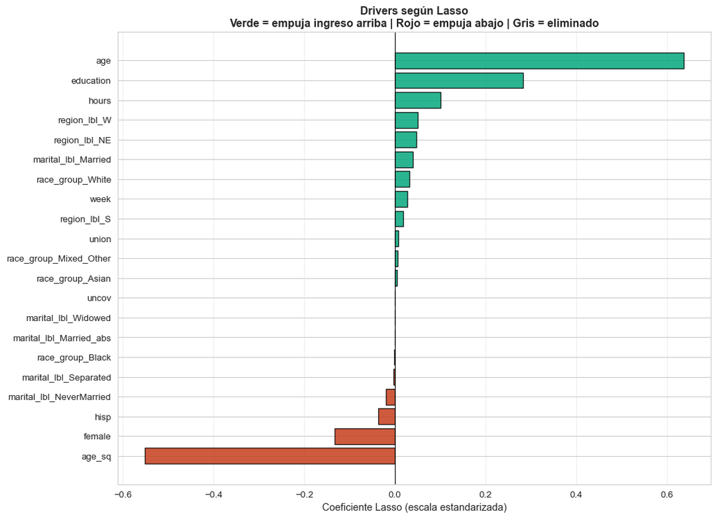

```python
# Coeficientes Lasso ordenados visualmente
lasso_coefs = pd.DataFrame({
    'feature': X_scaled.columns,
    'coef': lasso.coef_
}).sort_values('coef')

fig, ax = plt.subplots(figsize=(11, 8))
colors = [PALETTE['success'] if c > 0 else PALETTE['danger'] if c < 0 else PALETTE['neutral']
          for c in lasso_coefs['coef']]
ax.barh(lasso_coefs['feature'], lasso_coefs['coef'], color=colors, edgecolor='black', alpha=0.85)
ax.axvline(0, color='black', linewidth=0.8)
ax.set_xlabel('Coeficiente Lasso (escala estandarizada)')
ax.set_title('Drivers según Lasso\nVerde = empuja ingreso arriba | Rojo = empuja abajo | Gris = eliminado',
             fontweight='bold')
ax.grid(True, alpha=0.3, axis='x')
plt.tight_layout()
plt.show()
```

### 5.3 Árbol de decisión — reglas if-then visualizables

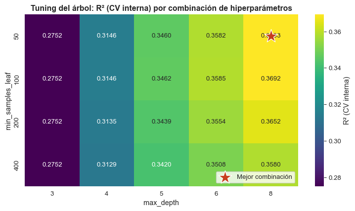

```
Mejores hiperparámetros: {'max_depth': 8, 'min_samples_leaf': 50}
R² CV interna (de la búsqueda): 0.3693
R² in-sample (todos los datos): 0.3868
→ La evaluación HONESTA (validación cruzada anidada) está en la sección 6.
```

```python
from sklearn.tree import DecisionTreeRegressor, plot_tree

# Espacio de búsqueda — rangos que FAVORECEN la regularización (anti-sobreajuste):
#   max_depth acotado y min_samples_leaf alto = hojas con suficientes datos.
tree_grid = {
    'max_depth':        [3, 4, 5, 6, 8],
    'min_samples_leaf': [50, 100, 200, 400],
}

# GridSearchCV prueba TODAS las combinaciones; cada una se puntúa con la CV interna,
# es decir en folds que no participaron en su ajuste → sin fuga de datos.
tree_search = GridSearchCV(
    DecisionTreeRegressor(random_state=RANDOM_STATE),
    tree_grid, cv=inner_cv, scoring='r2', n_jobs=-1
)
tree_search.fit(X, y)
tree = tree_search.best_estimator_   # mejor árbol, ya reajustado sobre todos los datos

# Visualizar el paisaje de la búsqueda: R² (CV interna) por combinación
tree_scores = (pd.DataFrame(tree_search.cv_results_)
               .pivot(index='param_min_samples_leaf', columns='param_max_depth',
                      values='mean_test_score')
               .sort_index().sort_index(axis=1))
fig, ax = plt.subplots(figsize=(8, 4.6))
sns.heatmap(tree_scores, annot=True, fmt='.4f', cmap='viridis',
            cbar_kws={'label': 'R² (CV interna)'}, ax=ax)
best_r, best_c = np.unravel_index(np.nanargmax(tree_scores.values), tree_scores.shape)
ax.scatter([best_c + 0.5], [best_r + 0.5], marker='*', s=450,
           color=PALETTE['danger'], edgecolor='white', zorder=5, label='Mejor combinación')
ax.set_title('Tuning del árbol: R² (CV interna) por combinación de hiperparámetros',
             fontweight='bold')
ax.set_xlabel('max_depth')
ax.set_ylabel('min_samples_leaf')
ax.legend(loc='lower right')
plt.tight_layout()
plt.show()

print(f"Mejores hiperparámetros: {tree_search.best_params_}")
print(f"R² CV interna (de la búsqueda): {tree_search.best_score_:.4f}")
print(f"R² in-sample (todos los datos): {tree.score(X, y):.4f}")
print("→ La evaluación HONESTA (validación cruzada anidada) está en la sección 6.")
```

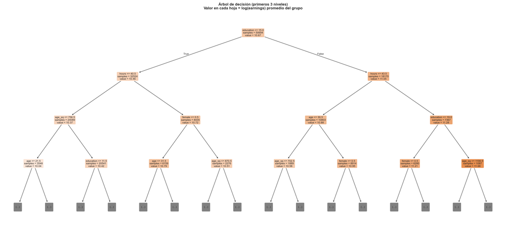

```python
# El árbol grande, completo
fig, ax = plt.subplots(figsize=(24, 11))
plot_tree(tree, feature_names=X.columns, filled=True, rounded=True,
          fontsize=9, max_depth=3, impurity=False, precision=2, ax=ax)
plt.title('Árbol de decisión (primeros 3 niveles)\nValor en cada hoja = log(earnings) promedio del grupo',
          fontweight='bold', fontsize=13)
plt.tight_layout()
plt.show()
```

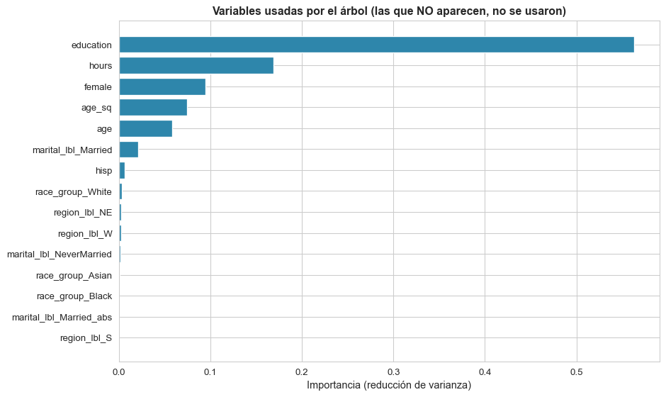

```python
# Feature importance del árbol
tree_imp = pd.DataFrame({
    'feature': X.columns,
    'importance': tree.feature_importances_
}).sort_values('importance', ascending=True)
tree_imp = tree_imp[tree_imp['importance'] > 0]

fig, ax = plt.subplots(figsize=(10, 6))
ax.barh(tree_imp['feature'], tree_imp['importance'], color=PALETTE['primary'], edgecolor='white')
ax.set_xlabel('Importancia (reducción de varianza)')
ax.set_title('Variables usadas por el árbol (las que NO aparecen, no se usaron)', fontweight='bold')
plt.tight_layout()
plt.show()
```